# XMM-LSS master catalogue

The catalogue comes from `dmu0_UKIDSS-UDS`.

In the catalogue, we keep:

- The identifier (it's unique in the catalogue);
- The position;
- The stellarity;
- The magnitude for each band in apertude 3 (2 arcsec).
- The kron magnitude to be used as total magnitude (no “auto” magnitude is provided).

The magnitudes are “*Vega like*”. The AB offsets are given by Hewett *et al.* (2016):

| Band | AB offset |
| --- | --- |
| J | 0.938 |
| H | 1.379 |
| K | 1.900 |

A query to the UKIDSS database with 242.9+55.071 position returns a list of images taken between 2007 and 2009. Let's take 2008 for the epoch. TODO: Update for UDS.

```python
from herschelhelp_internal import git_version
print("This notebook was run with herschelhelp_internal version: \n{}".format(git_version()))
```

```
This notebook was run with herschelhelp_internal version:
33f5ec7 (Wed Dec 6 16:56:17 2017 +0000)
```

```python
%matplotlib inline
#%config InlineBackend.figure_format = 'svg'

import matplotlib.pyplot as plt
plt.rc('figure', figsize=(10, 6))

from collections import OrderedDict
import os

from astropy import units as u
from astropy.coordinates import SkyCoord
from astropy.table import Column, Table
import numpy as np

from herschelhelp_internal.flagging import  gaia_flag_column
from herschelhelp_internal.masterlist import nb_astcor_diag_plot, remove_duplicates
from herschelhelp_internal.utils import astrometric_correction, mag_to_flux
```

```python
OUT_DIR =  os.environ.get('TMP_DIR', "./data_tmp")
try:
    os.makedirs(OUT_DIR)
except FileExistsError:
    pass

RA_COL = "uds_ra"
DEC_COL = "uds_dec"
```

## I - Column selection

```python
imported_columns = OrderedDict({
        'sourceid': 'uds_id',
        'RA': 'uds_ra',
        'Dec': 'uds_dec',
        'JAPERMAG3': 'm_ap_uds_j',
        'JAPERMAG3ERR': 'merr_ap_uds_j',
        'JKRONMAG': 'm_uds_j',
        'JKRONMAGERR': 'merr_uds_j',
        'HAPERMAG3': 'm_ap_uds_h',
        'HAPERMAG3ERR': 'merr_ap_uds_h',
        'HKRONMAG': 'm_uds_h',
        'HKRONMAGERR': 'merr_uds_h',
        'KAPERMAG3': 'm_ap_uds_k',
        'KAPERMAG3ERR': 'merr_ap_uds_k',
        'KKRONMAG': 'm_uds_k',
         'KKRONMAGERR': 'merr_uds_k',
         'PSTAR': 'uds_stellarity'
    })

catalogue = Table.read(
    "../../dmu0/dmu0_UKIDSS-UDS/data/UKIDSS-UDS_XMM-LSS.fits")[list(imported_columns)]
for column in imported_columns:
    catalogue[column].name = imported_columns[column]

epoch = 2008

# Clean table metadata
catalogue.meta = None
```

```
WARNING: UnitsWarning: 'degrees' did not parse as fits unit: At col 0, Unit 'degrees' not supported by the FITS standard.  [astropy.units.core]
```

```python
# Adding flux and band-flag columns
for col in catalogue.colnames:
    if col.startswith('m_'):

        errcol = "merr{}".format(col[1:])

        # DXS uses a huge negative number for missing values
        catalogue[col][catalogue[col] < -100] = np.nan
        catalogue[errcol][catalogue[errcol] < -100] = np.nan

        # Vega to AB correction
        if col.endswith('j'):
            catalogue[col] += 0.938
        elif col.endswith('h'):
            catalogue[col] += 1.379
        elif col.endswith('k'):
            catalogue[col] += 1.900
        else:
            print("{} column has wrong band...".format(col))

        flux, error = mag_to_flux(np.array(catalogue[col]), np.array(catalogue[errcol]))

        # Fluxes are added in µJy
        catalogue.add_column(Column(flux * 1.e6, name="f{}".format(col[1:])))
        catalogue.add_column(Column(error * 1.e6, name="f{}".format(errcol[1:])))

        # Band-flag column
        if "ap" not in col:
            catalogue.add_column(Column(np.zeros(len(catalogue), dtype=bool), name="flag{}".format(col[1:])))

# TODO: Set to True the flag columns for fluxes that should not be used for SED fitting.
```

```python
catalogue[:10].show_in_notebook()
```

<Table masked=True length=10>

| idx | uds_id | uds_ra degrees | uds_dec degrees | m_ap_uds_j | merr_ap_uds_j | m_uds_j | merr_uds_j | m_ap_uds_h | merr_ap_uds_h | m_uds_h | merr_uds_h | m_ap_uds_k | merr_ap_uds_k | m_uds_k | merr_uds_k | uds_stellarity | f_ap_uds_j | ferr_ap_uds_j | f_uds_j | ferr_uds_j | flag_uds_j | f_ap_uds_h | ferr_ap_uds_h | f_uds_h | ferr_uds_h | flag_uds_h | f_ap_uds_k | ferr_ap_uds_k | f_uds_k | … |
| --- | --- | --- | --- | --- | --- | --- | --- | --- | --- | --- | --- | --- | --- | --- | --- | --- | --- | --- | --- | --- | --- | --- | --- | --- | --- | --- | --- | --- | --- | --- |
| 0 | 450971566081 | 34.367870813 | -5.56541071827 | nan | nan | nan | nan | nan | nan | nan | nan | 20.0644 | 0.0475614 | 18.1974 | 0.025559 | 0.00703433 | nan | nan | nan | nan | False | nan | nan | nan | nan | False | 34.2181 | 1.49895 | 191.005 | … |
| 1 | 450971566082 | 34.7445474465 | -5.56147712705 | nan | nan | nan | nan | nan | nan | nan | nan | 13.8005 | 0.00276986 | 13.6802 | 0.00259286 | 0.695518 | nan | nan | nan | nan | False | nan | nan | nan | nan | False | 10960.1 | 27.9606 | 12243.6 | … |
| 2 | 450971566083 | 34.3047073198 | -5.56223642153 | 19.0275 | 0.0897175 | 17.2939 | 0.0397843 | nan | nan | nan | nan | 18.6303 | 0.0214489 | 16.977 | 0.0112291 | 0.00110084 | 88.9229 | 7.34795 | 438.99 | 16.0858 | False | nan | nan | nan | nan | False | 128.195 | 2.53251 | 587.744 | … |
| 3 | 450971566084 | 34.3003289695 | -5.56557280323 | nan | nan | nan | nan | nan | nan | nan | nan | 21.7937 | 0.137446 | 21.5441 | 0.134229 | 0.00703433 | nan | nan | nan | nan | False | nan | nan | nan | nan | False | 6.95874 | 0.880926 | 8.75681 | … |
| 4 | 450971566085 | 34.3562070077 | -5.56551766795 | nan | nan | nan | nan | nan | nan | nan | nan | 22.8524 | 0.329595 | 22.8094 | 0.310351 | 0.00703433 | nan | nan | nan | nan | False | nan | nan | nan | nan | False | 2.62447 | 0.796705 | 2.73054 | … |
| 5 | 450971566086 | 34.2901770877 | -5.56547068484 | nan | nan | nan | nan | nan | nan | nan | nan | 24.7111 | 1.74357 | 24.3629 | 1.22133 | 0.26296 | nan | nan | nan | nan | False | nan | nan | nan | nan | False | 0.473751 | 0.760789 | 0.652908 | … |
| 6 | 450971566087 | 34.3925766316 | -5.56549696485 | nan | nan | nan | nan | nan | nan | nan | nan | 23.3221 | 0.493141 | 23.391 | 0.521536 | 0.00703433 | nan | nan | nan | nan | False | nan | nan | nan | nan | False | 1.70273 | 0.773379 | 1.59808 | … |
| 7 | 450971566088 | 34.367499354 | -5.56542091583 | nan | nan | nan | nan | nan | nan | nan | nan | 20.3923 | 0.0569566 | 19.0428 | 0.0331051 | 0.00703433 | nan | nan | nan | nan | False | nan | nan | nan | nan | False | 25.298 | 1.32711 | 87.672 | … |
| 8 | 450971566089 | 34.0377303354 | -5.56527529519 | nan | nan | nan | nan | nan | nan | nan | nan | 21.1706 | 0.216454 | 21.0224 | 0.201029 | 0.00703433 | nan | nan | nan | nan | False | nan | nan | nan | nan | False | 12.3522 | 2.46256 | 14.1595 | … |
| 9 | 450971566090 | 34.3685481147 | -5.565392882 | nan | nan | nan | nan | nan | nan | nan | nan | 20.4193 | 0.0580855 | 18.7035 | 0.0276927 | 0.00703433 | nan | nan | nan | nan | False | nan | nan | nan | nan | False | 24.6753 | 1.3201 | 119.841 | … |

## II - Removal of duplicated sources

We remove duplicated objects from the input catalogues.

```python
SORT_COLS = ['merr_ap_uds_j', 'merr_ap_uds_h', 'merr_ap_uds_k']
FLAG_NAME = 'uds_flag_cleaned'

nb_orig_sources = len(catalogue)

catalogue = remove_duplicates(catalogue, RA_COL, DEC_COL, sort_col=SORT_COLS, flag_name=FLAG_NAME)

nb_sources = len(catalogue)

print("The initial catalogue had {} sources.".format(nb_orig_sources))
print("The cleaned catalogue has {} sources ({} removed).".format(nb_sources, nb_orig_sources - nb_sources))
print("The cleaned catalogue has {} sources flagged as having been cleaned".format(np.sum(catalogue[FLAG_NAME])))
```

```
The initial catalogue had 296026 sources.
The cleaned catalogue has 296026 sources (0 removed).
The cleaned catalogue has 0 sources flagged as having been cleaned
```

## III - Astrometry correction

We match the astrometry to the Gaia one. We limit the Gaia catalogue to sources with a g band flux between the 30th and the 70th percentile. Some quick tests show that this give the lower dispersion in the results.

```python
gaia = Table.read("../../dmu0/dmu0_GAIA/data/GAIA_XMM-LSS.fits")
gaia_coords = SkyCoord(gaia['ra'], gaia['dec'])
```

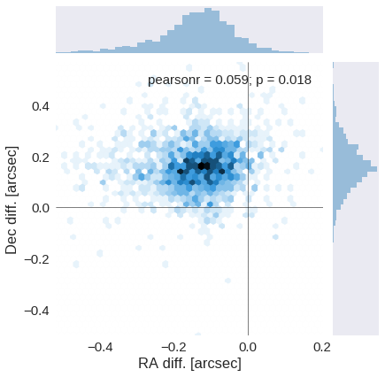

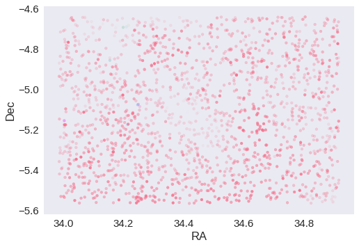

```python
nb_astcor_diag_plot(catalogue[RA_COL], catalogue[DEC_COL],
                    gaia_coords.ra, gaia_coords.dec)
```

```python
delta_ra, delta_dec =  astrometric_correction(
    SkyCoord(catalogue[RA_COL], catalogue[DEC_COL]),
    gaia_coords
)

print("RA correction: {}".format(delta_ra))
print("Dec correction: {}".format(delta_dec))
```

```
RA correction: 0.12895760060445127 arcsec
Dec correction: -0.15744215684776464 arcsec
```

```python
catalogue[RA_COL] +=  delta_ra.to(u.deg)
catalogue[DEC_COL] += delta_dec.to(u.deg)
```

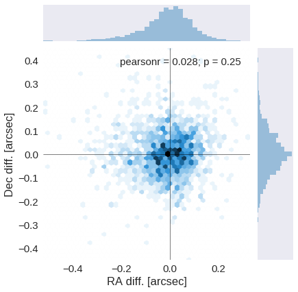

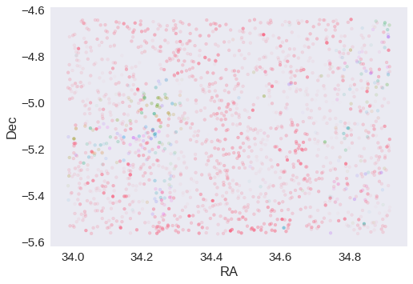

```python
nb_astcor_diag_plot(catalogue[RA_COL], catalogue[DEC_COL],
                    gaia_coords.ra, gaia_coords.dec)
```

## IV - Flagging Gaia objects

```python
catalogue.add_column(
    gaia_flag_column(SkyCoord(catalogue[RA_COL], catalogue[DEC_COL]), epoch, gaia)
)
```

```python
GAIA_FLAG_NAME = "uds_flag_gaia"

catalogue['flag_gaia'].name = GAIA_FLAG_NAME
print("{} sources flagged.".format(np.sum(catalogue[GAIA_FLAG_NAME] > 0)))
```

```
1683 sources flagged.
```

# V - Saving to disk

```python
catalogue.write("{}/UKIDSS-UDS.fits".format(OUT_DIR), overwrite=True)
```